# Sampling and Population Characteristics

Descriptive Inference

Jeremy Springman

University of Pennsylvania

**Global Development**: Intermediate Topics in Politics, Policy, and Data

PSCI 3200 - Spring 2025

# Logistics

## Assignments

- Today
  - Read Ch 3
  - Install Quarto and create an empty html
- Thursday
  - Read Ch 4
  - Create a git repo for this class (psci3200_yourname)

## Agenda

1. Finishing up Causality 1
2. Inferring Population Characteristics via Survey Research
3. Messing around in Quarto
4. Final Project

# Finishing up Causality 1

## Identifying Assumptions

- You must control for…
  - everything (observed and unobserved) that affects both the treatment variable and the outcome variable
- You *must not* control for…
  - anything that is affected by both the treatment variable and the outcome variable

## Colliders

[figure not shown]

## Colliders

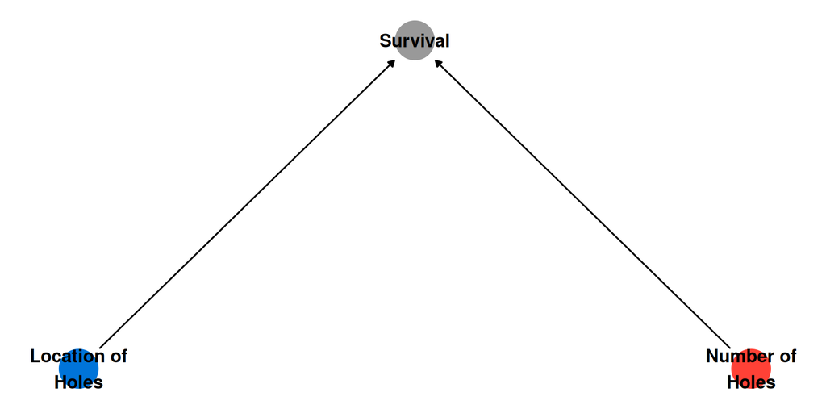

## Plumbing vs Science

- Scientists can tell us the drivers of human welfare and prosperity
  - Can we manipulate these macro-forces? Probably not.
- So what can we do as social scientists?
  - Help at the margins in specific places with specific policies and programs
- Any normatively uncomfortable findings?

# Inferring Population Characteristics via Survey Research

## Survey Research

- We often want to *describe* a population of interest
  - Examples?
  - How is this different from correlation?
- We usually can’t collect data on the entire population
- Sampling allows us to estimate population characteristics from a *subset* of the population
- Random sampling makes it most likely that our sample is *representative* of the population

## Getting a Representative Samples

- Sampling frame
  - Comprehensive list of units
  - Ideally: Census, administrative records
  - Developing contexts: create this yourself on-the-ground
- Non-response
  - Selection into sample can bias estimates, induce spurious relationships
  - Think about collider example

## Dealing with Missingness

- Unit non-response
  - Incentives
  - Fancy weighting
- Item non-response
  - Self-administration
- Misreporting
  - List experiments

## Dealing with Missingness

- Always look at NAs immediately
- Always think about how this might bias estimates

## Sampling Strategies

- Probability sampling strategies:
  - Simple random sampling
  - Stratified sampling
  - Cluster sampling
- Non-Probability sampling strategies:
  - Convenience sample

## Simple Random Sampling

- Each unit within the population has the same probability of being chosen
- As size increases, the sample more closely resemble the population
- Assumes that unit and item non-response are effectively random

## Stratified sampling

- Divide the entire population into *homogeneous* strata
- Take random samples from each stratum
  - Decreases risk of imbalance
  - Ex. Race, gender, partisanship
- Oversampling
  - Allows for more precise estimates of small group characteristics
  - Must adjust for population estimates

## Cluster sampling

- Divide population into *heterogeneous* clusters
- Take random sample of clusters
  - Decreases costs of sampling
  - Ex. Districts, schools, businesses

# Final Project Discussion

## Final Project

- Data analysis project with data of your choosing
  - Formulate a research question
  - Find data that can help you answer that question
  - Apply the tools and methods from this course
  - Write-up analysis
- Produce a webpage to present your results for public consumption

## Write-up

1. Introduction to research question and data
2. Discussion of research design, assumptions, and threats to inference
3. Visualization describing your data
4. Presentation of results from a regression model and discussion of implications for research question
5. Discussion of policy implications

## Public Datasets

- Varieties of Democracy
- Machine Learning for Peace
- Afrobarometer, Arab Barometer
- Armed Conflict Location & Event Data Project (ACLED)
- AidData

## My Datasets

- Cambodian NGOs (n $\approx$ 100)
  - Convenience sample
  - Panel survey, financial data, networks, open-ended responses
- Ethiopian University Students (n $\approx$ 900)
  - Representative sample
  - Panel survey, networks, open-ended responses
- Ghanaian Radio Stations (n $\approx$ 400)
  - Convenience sample

## DevLab Datasets

- Too many to recall, but inquire with me and I will ask around

## Final Project

| Milestone | Due Date |
| --- | --- |
| Create a GitHub repository | Feb 8th |
| Identify data source | Mar 5th |
| Submit proposal | Apr 2nd |
| Submit final project | May 2nd |

# RStudio and Quarto

## Poll

- Mac vs Windows?
- Quarto running?

## Instructions

- Follow-along as I create a quarto page
- Submit the html for the page to me via Slack *before* the end of class

[figure not shown]

jrspringman.github.io/psci3200-globaldev/